# Image Compression using Singular Value Decomposition with R program

The singular value decomposition can also be used to produce an approximation to a given $n \times d$ matrix, $\mathbf{X}$. For example, let the singular value decomposition of $\mathbf{X}$ be
$$\mathbf{X}= \mathbf{U} \mathbf{D}_{\lambda}
{\mathbf{V}}^{\mkern-1.5mu\mathsf{T}}$$
where $\mathbf{U} = [\mathbf{U}_1, \mathbf{U}_2, \ldots , \mathbf{U}_d]$, $\mathbf{D}_{\lambda} = diag(\lambda_1, \lambda_2, \ldots , \lambda_d)$, and $\mathbf{V} = [\mathbf{v}_1, \mathbf{v}_2, \ldots , \mathbf{v}_d]$.

Suppose we choose $r < d$, then the matrix
$$\widehat{\mathbf{X}}=
\sum_{i=1}^r \lambda_i \mathbf{U}_i
{\mathbf{v}_i}^{\mkern-1.5mu\mathsf{T}} = \widehat{\mathbf{U}} \widehat{
\mathbf{D}}_{\lambda}
\widehat{ \mathbf{V}}^T$$

where $\widehat{\mathbf{U}}=[\mathbf{U}_1, \mathbf{U}_2, \ldots , \mathbf{U}_r]$, $\widehat{\mathbf{D}}_{\lambda} = diag(\lambda_1, \lambda_2, \ldots , \lambda_r)$, and $\widehat{\mathbf{V}} = [\mathbf{v}_1, \mathbf{v}_2, \ldots , \mathbf{v}_r]$ can be regarded as an approximation to the original matrix $\mathbf{X}$.

Below, I am simply going to investigate the quality of this approximation on a particular example.

The original matrix $\mathbf{X}$ requires $n \times d$ numbers to be stored in an array. The approximation, $\widehat{\mathbf{X}}$, contains as many numbers but need not be represented this way. Instead, only the numbers contained in the matrices $\widehat{\mathbf{U}}$, $\widehat{\mathbf{D}}_{\lambda}$, and $\widehat{\mathbf{V}}$.

$\widehat{\mathbf{U}}$ has dimension $n\times r$.$\widehat{\mathbf{D}}_{\lambda}$ has dimension $r\times r$. $\widehat{\mathbf{V}}$ has dimension $d \times r$. However, $\widehat{\mathbf{D}}_{\lambda}$ only have r non-zero entries as it is a diagonal matrix.

Therefore, the total number that must be held to reproduce $\widehat{\mathbf{X}}$ is $n\times r + r + d \times r$.

$\mathbf{X}$ has a dimension of $n \times d$. Thus, we need to store $n \times d$ numbers.  
The approximation will require fewer numbers than the original matrix if $n\times r + r + d \times r < n \times d$.

For example, for $n = 147$ and $d = 104$, $r < 60.666$. Therefore, $r$ will need to be smaller than 60 for the approximation to require fewer numbers to be stored.

Below, I calculated the singular value decomposition of `bb` and plot the corresponding values of $\lambda_i / \lambda_1$ versus $i$.

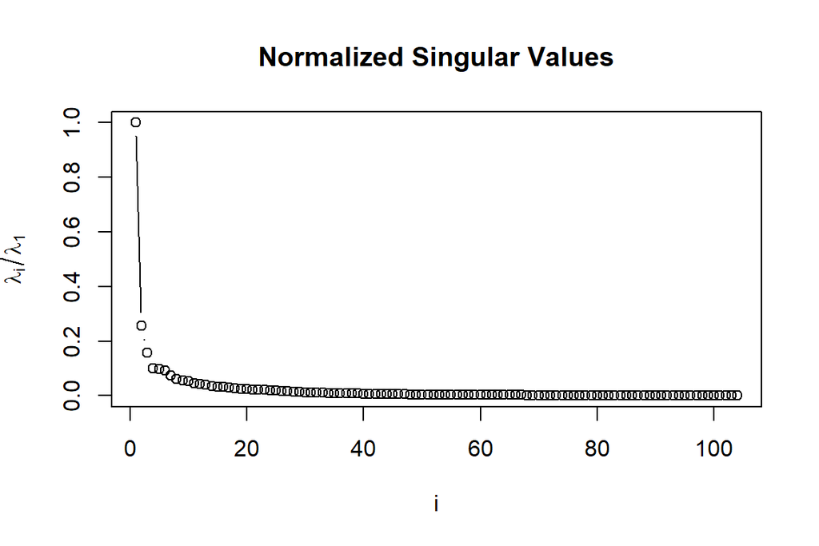

```r
    source("bb.R")

    bb <- matrix(scan("bbdata.R",sep=","),
                                 nrow=147,ncol=104,byrow=TRUE)

    svd_values <- svd(bb)

    singular_values <- svd_values$d

    # Normalizing by the first singular value
    normalized_singular_values <- singular_values / singular_values[1]

    # Plotting
    plot(normalized_singular_values, type = "b", xlab = "i", ylab = expression(lambda[i] / lambda[1]),
         main = "Normalized Singular Values")
```

Based on this plot, I would guess a value of 15 might be to provide an adequate approximation as the marginal benefit of further increasing the dimension is low.

Suppose that an approximation, `newbb`, (or $\widehat{\mathbf{X}}$), of `bb` (or $\mathbf{X}$) is constructed based on `dim` (or $r$) dimensions.

Below, I produced **five** such approximations (for $r=5, 10, 15, 20, 40$) and display them in a single plot, along with the picture of the original matrix.

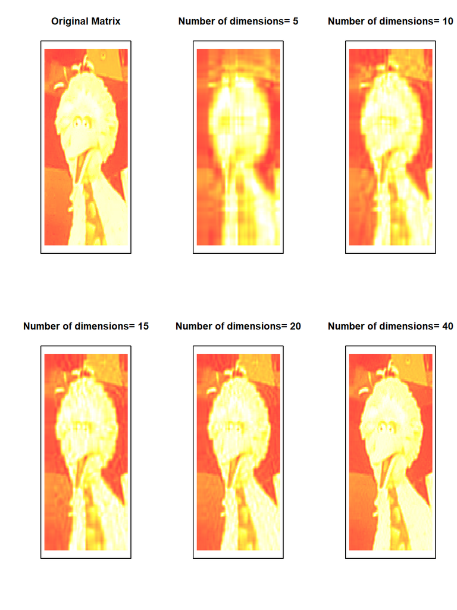

```r
    par(mfrow = c(2, 3))

    breaks <- seq(0,256,1)
    cols <- heat.colors(256,alpha=0.75)
    col_areas(bb, breaks, cols, main = "Original Matrix")

    plot_approximation <- function(r) {
      U_r <- svd_values$u[, 1:r]
      D_r <- diag(svd_values$d[1:r])
      V_r <- svd_values$v[, 1:r]
      newbb <- U_r %*% D_r %*% t(V_r)
      col_areas(newbb, breaks, cols, main = paste("Number of dimensions=", r))
    }

    for (r in c(5, 10, 15, 20, 40)) {
      plot_approximation(r)
    }
```